### Predicting the class of performing weight lifting exercises

#### Background

This project is to predict the manner/class in which people did the exercise based on the provided data (http://groupware.les.inf.puc-rio.br/har). The data for this project recorded six participants who were asked to perform barbell lifts correctively and incorrectly in 5 different ways. Two datasets, training and testing, were provided. Each dataset contains recorded variables that we will use to predict the outcome ‘classe’ which represents the class. It is a factor variable(levels: A,B,C,D,E) only appears in training dataset. We are trying to build a model based on training dataset, verify on validation dataset, finally predict the ‘classe’ for each of the 20 observations in the testing dataset.

#### Data Cleaning

1. load in raw data

```r
    raw_data <- read.csv("c:/DataScience_Machine/project/pml-training.csv")
    testing <- read.csv("c:/DataScience_Machine/project/pml-testing.csv")
    dim(raw_data)
```

```
## [1] 19622   160
```

There are 19622 observations with 160 variables, ‘classe’ is the last one; after studied, we decided to take out column 1:7 because it won’t affect the prediction

2. take out column 1 to column 7

```r
    data1 <- raw_data[, -c(1:7)]
    dim(data1)
```

```
## [1] 19622   153
```

Now, it is down to 19622 observations with 153 variables

3. take care missing value and NA, first make all missing value as NA, then only take those columns with NA < 2000 (allows maximum 10% NA in 1 column)

```r
    data1[data1==""] <- NA
    data2 <- data1[colSums(is.na(data1)) < 2000]
    dim(data2)
```

```
## [1] 19622    53
```

Up to this point, it is down to 19622 observations with 53 variables

#### Model 1: take out highly related variables, build model and predict

1. check correlation between variables except with ‘classe’, find the highly correlated variables based on Cohen Effective size(cor > 0.5, absolute value)

```r
   cor_table <- cor(data2[,-dim(data2)[2]],)
   high_cor <- findCorrelation(cor_table, cutoff=0.5)
   length(high_cor)
```

```
## [1] 31
```

There are 31 variables highly correlated, take out those highly correlated variables and make our cleaned dataset(data)

```r
    data <- data2[, -high_cor]
    dim(data)
```

```
## [1] 19622    22
```

```r
    names(data)
```

```
##  [1] "gyros_belt_x"        "gyros_belt_y"        "gyros_belt_z"
##  [4] "magnet_belt_z"       "roll_arm"            "pitch_arm"
##  [7] "yaw_arm"             "total_accel_arm"     "gyros_arm_x"
## [10] "gyros_arm_z"         "roll_dumbbell"       "pitch_dumbbell"
## [13] "gyros_dumbbell_z"    "roll_forearm"        "pitch_forearm"
## [16] "yaw_forearm"         "total_accel_forearm" "gyros_forearm_x"
## [19] "accel_forearm_z"     "magnet_forearm_x"    "magnet_forearm_y"
## [22] "classe"
```

Here, we get our cleaned dataset: 19622 observations with 22 variables where 1 outcome variable ‘classe’ and 21 predictors

2. make Training and Validation data set. For training purpose, we split the cleaned dataset(data) into two dataset: Training (60%) and Validation (40%)

```r
    inTrain <- createDataPartition(data$classe, p=0.6, list=FALSE)
    training <- data[inTrain,]
    validation <- data[-inTrain,]
    dim(training)
```

```
## [1] 11776    22
```

```r
    dim(validation)
```

```
## [1] 7846   22
```

In training dataset, there are 11776 observations with 22 variables. In validation dataset, there are 7846 observations with 22 variables

3. build Model from Training dataset & Predict on validation dataset using randomForest method

```r
    set.seed(111)
    modelFit <- train(classe~., method="rf", data=training, trControl=trainControl(method="cv"), importance=TRUE)
    set.seed(222)
    predict_valid <- predict(modelFit, newdata=validation)
    confMat <- confusionMatrix(predict_valid, validation$classe)
    confMat$table
```

```
##           Reference
## Prediction    A    B    C    D    E
##          A 2226   21    3    0    0
##          B    4 1464   15    3    1
##          C    0   27 1342   40    0
##          D    2    4    8 1228    1
##          E    0    2    0   15 1440
```

From confusionMatrix, it shows that this model has accuracy of 98%, it means the out of sample error is 2% while apply on our validation dataset

1. make Training and Validation dataset. Here, we get our cleaned dataset(data2): 19622 observations with 53 variables where 1 outcome variable ‘classe’ and 52 predictors. For training purpose, we split the cleaned dataset(data2) into two dataset: Train (60%) and Valid (40%)

```r
    inTrain_PCA <- createDataPartition(data2$classe, p=0.6, list=FALSE)
    train <- data2[inTrain_PCA,]
    valid <- data2[-inTrain_PCA,]
    dim(train)
```

```
## [1] 11776    53
```

```r
    dim(valid)
```

```
## [1] 7846   53
```

```r
    names(data2)
```

```
##  [1] "roll_belt"            "pitch_belt"           "yaw_belt"
##  [4] "total_accel_belt"     "gyros_belt_x"         "gyros_belt_y"
##  [7] "gyros_belt_z"         "accel_belt_x"         "accel_belt_y"
## [10] "accel_belt_z"         "magnet_belt_x"        "magnet_belt_y"
## [13] "magnet_belt_z"        "roll_arm"             "pitch_arm"
## [16] "yaw_arm"              "total_accel_arm"      "gyros_arm_x"
## [19] "gyros_arm_y"          "gyros_arm_z"          "accel_arm_x"
## [22] "accel_arm_y"          "accel_arm_z"          "magnet_arm_x"
## [25] "magnet_arm_y"         "magnet_arm_z"         "roll_dumbbell"
## [28] "pitch_dumbbell"       "yaw_dumbbell"         "total_accel_dumbbell"
## [31] "gyros_dumbbell_x"     "gyros_dumbbell_y"     "gyros_dumbbell_z"
## [34] "accel_dumbbell_x"     "accel_dumbbell_y"     "accel_dumbbell_z"
## [37] "magnet_dumbbell_x"    "magnet_dumbbell_y"    "magnet_dumbbell_z"
## [40] "roll_forearm"         "pitch_forearm"        "yaw_forearm"
## [43] "total_accel_forearm"  "gyros_forearm_x"      "gyros_forearm_y"
## [46] "gyros_forearm_z"      "accel_forearm_x"      "accel_forearm_y"
## [49] "accel_forearm_z"      "magnet_forearm_x"     "magnet_forearm_y"
## [52] "magnet_forearm_z"     "classe"
```

In training dataset, there are 11776 observations with 53 variables. In validation dataset, there are 7846 observations with 53 variables

```r
    set.seed(1111)
    modFit <- train(classe~., method="rf", data=train, trControl=trainControl(method="cv"), Preprocess="pca",importance=TRUE)
    set.seed(2222)
    pre_valid <- predict(modFit, newdata=valid)
    con_Mat <- confusionMatrix(pre_valid, valid$classe)
    con_Mat$table
```

```
##           Reference
## Prediction    A    B    C    D    E
##          A 2225   18    0    0    0
##          B    6 1496    7    1    0
##          C    0    4 1358   16    3
##          D    0    0    3 1266    7
##          E    1    0    0    3 1432
```

From confusionMatrix, it shows that this model has accuracy of 99.12%, that means the out of sample error is 0.88% while apply on our validation dataset

#### Some analysis of final model(modFit):

1. importance of predictors (top20) 2. predicted vs. truth on validation dataset

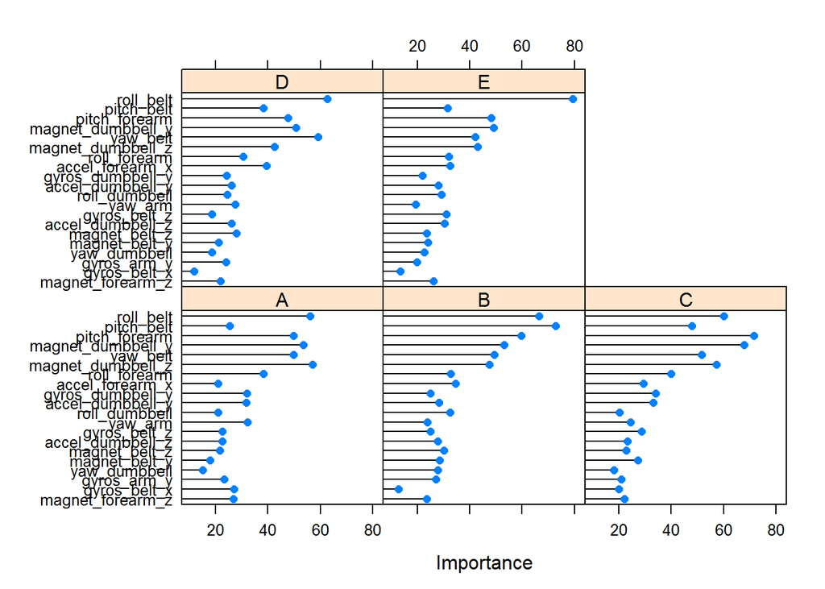

```r
    imp <- varImp(modFit, scale = FALSE)
    plot(imp, top=20)
```

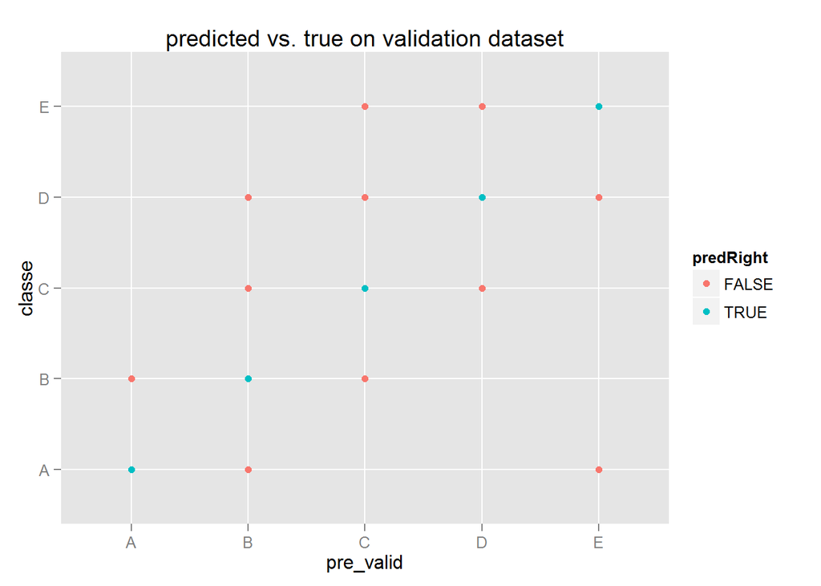

```r
    valid$predRight <- pre_valid==valid$classe
    qplot( pre_valid, classe, data=valid, color=predRight, main="predicted vs. true on validation dataset")
```

#### Apply on Testing dataset using final model (modFit)

```r
    answers <- predict(modFit, newdata=testing)
    print(answers)
```

```
##  [1] B A B A A E D B A A B C B A E E A B B B
## Levels: A B C D E
```

Now, we save/write the answers in files

```r
    pml_write_files = function(x){
        n = length(x)
        for (i in 1:n){
            filename = paste0("problem_id",i,".txt")
            write.table(x[i],file=filename,quote=FALSE,row.name=FALSE,col.names=FALSE)
        }
    }
    pml_write_files(answers)
```